# The Berries Project

Yu Du  
10/19/2020

### The Introduction

The data were stored online at Nass Website, and then downloaded as a CSV file, and the data contains three commodities:rasperries, bluberries, strawberries. Focused on: Strawberries. The project is designed to analyze on the strawberries' yields and find whether the chemical applied to strawberries in states has an effect on the yield of strawberries in different locations.

### Acquire and read the data

```r
library(knitr)
library(tidyverse)
library(magrittr)
library(kableExtra)
library(stats)
library(ggplot2)
strbb <- read_csv("/Users/duyu/Downloads/berries.csv")
strbb%>% summarize_all(n_distinct) -> aa
bb <- which(aa[1,]==1)
strbb %<>% select(-all_of(bb))
aa %<>% select(-all_of(bb))
strbb %<>% select(-4)
aa %<>% select(-4)
```

```r
kable(head(strbb, n=8)) %>% kable_styling(font_size=12)
```

| Year | Period | State | Commodity | Data Item | Domain | Domain Category | Value |
| --- | --- | --- | --- | --- | --- | --- | --- |
| 2019 | MARKETING YEAR | CALIFORNIA | BLUEBERRIES | BLUEBERRIES, TAME - PRICE RECEIVED, MEASURED IN $ / LB | TOTAL | NOT SPECIFIED | 2.85 |
| 2019 | MARKETING YEAR | CALIFORNIA | BLUEBERRIES | BLUEBERRIES, TAME, FRESH MARKET - PRICE RECEIVED, MEASURED IN $ / LB | TOTAL | NOT SPECIFIED | 3.56 |
| 2019 | MARKETING YEAR | CALIFORNIA | BLUEBERRIES | BLUEBERRIES, TAME, PROCESSING - PRICE RECEIVED, MEASURED IN $ / LB | TOTAL | NOT SPECIFIED | 0.29 |
| 2019 | MARKETING YEAR | CALIFORNIA | RASPBERRIES | RASPBERRIES - PRICE RECEIVED, MEASURED IN $ / LB | TOTAL | NOT SPECIFIED | 2.69 |
| 2019 | MARKETING YEAR | CALIFORNIA | RASPBERRIES | RASPBERRIES, FRESH MARKET - PRICE RECEIVED, MEASURED IN $ / LB | TOTAL | NOT SPECIFIED | (D) |
| 2019 | MARKETING YEAR | CALIFORNIA | RASPBERRIES | RASPBERRIES, PROCESSING - PRICE RECEIVED, MEASURED IN $ / LB | TOTAL | NOT SPECIFIED | (D) |
| 2019 | MARKETING YEAR | CALIFORNIA | STRAWBERRIES | STRAWBERRIES - PRICE RECEIVED, MEASURED IN $ / CWT | TOTAL | NOT SPECIFIED | 108 |
| 2019 | MARKETING YEAR | CALIFORNIA | STRAWBERRIES | STRAWBERRIES, FRESH MARKET - PRICE RECEIVED, MEASURED IN $ / CWT | TOTAL | NOT SPECIFIED | (D) |

### Select on the "Strawberries" commodity and "year" time period

```r
strb <- strbb %>% filter((Commodity=="STRAWBERRIES") & (Period=="YEAR"))
kable(head(strb, n=5)) %>% kable_styling(font_size=12)
```

| Year | Period | State | Commodity | Data Item | Domain | Domain Category | Value |
| --- | --- | --- | --- | --- | --- | --- | --- |
| 2019 | YEAR | CALIFORNIA | STRAWBERRIES | STRAWBERRIES - ACRES HARVESTED | TOTAL | NOT SPECIFIED | 35,400 |
| 2019 | YEAR | CALIFORNIA | STRAWBERRIES | STRAWBERRIES - ACRES PLANTED | TOTAL | NOT SPECIFIED | 36,000 |
| 2019 | YEAR | CALIFORNIA | STRAWBERRIES | STRAWBERRIES - PRODUCTION, MEASURED IN $ | TOTAL | NOT SPECIFIED | 2,221,320,000 |
| 2019 | YEAR | CALIFORNIA | STRAWBERRIES | STRAWBERRIES - PRODUCTION, MEASURED IN CWT | TOTAL | NOT SPECIFIED | 20,500,000 |
| 2019 | YEAR | CALIFORNIA | STRAWBERRIES | STRAWBERRIES - YIELD, MEASURED IN CWT / ACRE | TOTAL | NOT SPECIFIED | 580 |

### Remove rows containing NA or D value.(D: withheld to avoid disclosing data for individual operations.)

```r
strb<-strb %>% filter((Value != "(D)")&(Value !=  "(NA)"))
kable(head(strb, n=5)) %>% kable_styling(font_size=12)
```

[output not shown]

### Plot with each state's yield.

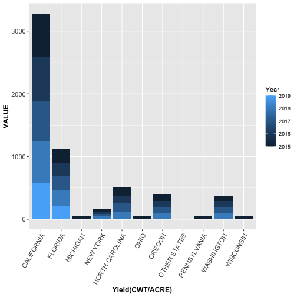

California and Florida are the top two strawberry producing states within the U.S.

### Plot with the total yield.

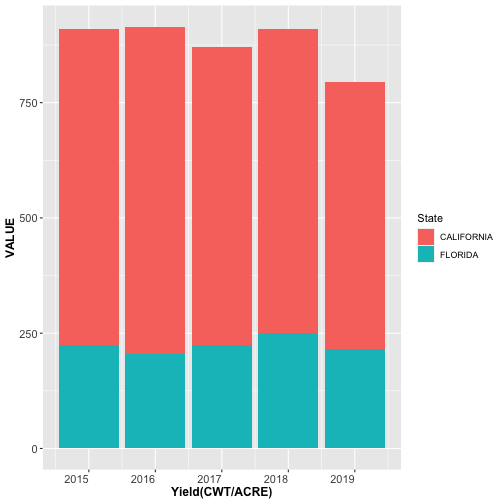

### Select INSECTICIDE with one measure. (only California and Florida have)

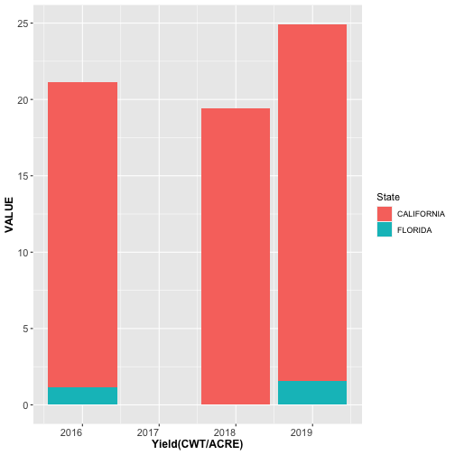

### Select FUNGICIDE

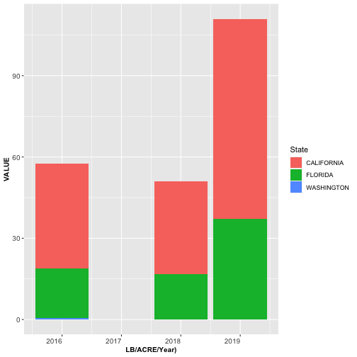

### Chemicals

For all chemicals, 2015 and 2017 do not have the data. Some states do not have the data. For “HERBICIDE” and “OTHER” chemicals, only California has.

### Conclusion

The total yield of California is more than twice as much as Florida has in each year. For chemicals, only have years in: 2016, 2018, 2019, and states in: California, Florida,Washington. A lot of rows in the data containing NA or D value in the last column.